# EasyVisa Project

## Bagging Classifier Model

### Bagging Classifier

```python
bagging_classifier = BaggingClassifier(random_state=1) ## Complete the code to define bagging classifier with random state = 1
bagging_classifier.fit(X_train,y_train) ## Complete the code to fit bagging classifier on the train data
```

```
BaggingClassifier(random_state=1)
```

#### Checking model performance on training set

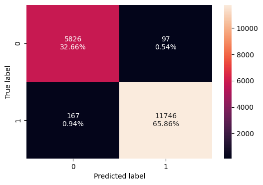

```python
## Complete the code to create confusion matrix for train data
confusion_matrix_sklearn(bagging_classifier, X_train, y_train)
```

```python
## Complete the code to check performance on train data
bagging_classifier_model_train_perf = model_performance_classification_sklearn(bagging_classifier, X_train, y_train)
bagging_classifier_model_train_perf
```

|  | Accuracy | Recall | Precision | F1 |
| --- | --- | --- | --- | --- |
| 0 | 0.985198 | 0.985982 | 0.99181 | 0.988887 |

#### Checking model performance on test set

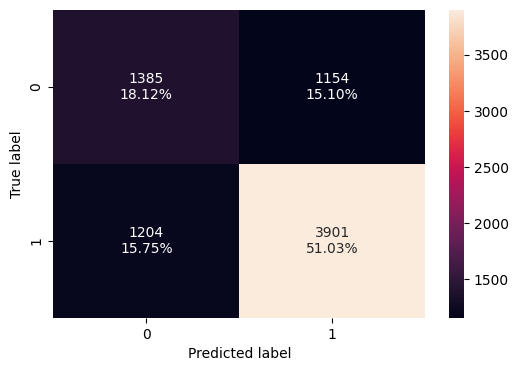

```python
## Complete the code to create confusion matrix for test data
confusion_matrix_sklearn(bagging_classifier, X_test, y_test)
```

```python
## Complete the code to check performance for test data
bagging_classifier_model_test_perf = model_performance_classification_sklearn(bagging_classifier, X_test, y_test)
bagging_classifier_model_test_perf
```

|  | Accuracy | Recall | Precision | F1 |
| --- | --- | --- | --- | --- |
| 0 | 0.691523 | 0.764153 | 0.771711 | 0.767913 |

*Observations*

The bagging classifier gives an F1 Score of 0.988 on the train data, and 0.767 on the test data, a clear indication that there's overfitting in the train data.

We can reduce the overfitting and improve performance by hyperparameter tuning.

### Hyperparameter Tuning - Bagging Classifier

```python
# Choose the type of classifier.
bagging_estimator_tuned = BaggingClassifier(random_state=1)

# Grid of parameters to choose from
parameters = {
    "max_samples": [0.7, 0.8],
    "max_features": [0.5,0.7,1],
    "n_estimators": np.arange(50,110,25),
}

# Type of scoring used to compare parameter combinations
acc_scorer = metrics.make_scorer(metrics.f1_score)

# Run the grid search
grid_obj = GridSearchCV(bagging_estimator_tuned, parameters, scoring=scorer,cv=5)  ## Complete the code to run grid search with cv = 5
grid_obj = grid_obj.fit(X_train, y_train) ## Complete the code to fit the grid_obj on train data

# Set the clf to the best combination of parameters
bagging_estimator_tuned = grid_obj.best_estimator_

# Fit the best algorithm to the data.
bagging_estimator_tuned.fit(X_train, y_train)
```

```
BaggingClassifier(max_features=0.7, max_samples=0.7, n_estimators=100,
                  random_state=1)
```

#### Checking model performance on training set

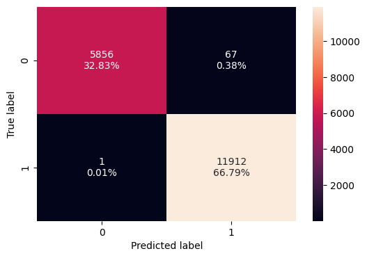

```python
## Complete the code to create confusion matrix for train data on tuned estimator
confusion_matrix_sklearn(bagging_estimator_tuned,X_train,y_train)
```

```python
## Complete the code to check performance for train data on tuned estimator
bagging_estimator_tuned_model_train_perf = model_performance_classification_sklearn(bagging_estimator_tuned,X_train,y_train)
bagging_estimator_tuned_model_train_perf
```

|  | Accuracy | Recall | Precision | F1 |
| --- | --- | --- | --- | --- |
| 0 | 0.996187 | 0.999916 | 0.994407 | 0.997154 |

#### Checking model performance on test set

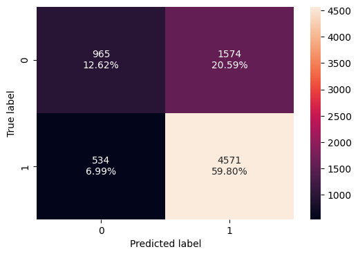

```python
## Complete the code to create confusion matrix for test data on tuned estimator
confusion_matrix_sklearn(bagging_estimator_tuned,X_test,y_test)
```

```python
## Complete the code to check performance for test data on tuned estimator
bagging_estimator_tuned_model_test_perf = model_performance_classification_sklearn(bagging_estimator_tuned,X_test,y_test)
bagging_estimator_tuned_model_test_perf
```

|  | Accuracy | Recall | Precision | F1 |
| --- | --- | --- | --- | --- |
| 0 | 0.724228 | 0.895397 | 0.743857 | 0.812622 |

*Observations* F1 Score for the train data is 0.99, and for the test data is 0.81. The bagging classifier is overfitting with the train data even after the hyperparameter tuning.